# Exploración de Quarto: informe de trigo duro bajo calor en tres formatos

Exploración libre de Quarto — datos simulados

Autor/a

Paul López

Fecha de publicación

20 de noviembre de 2026

**Código**

```r
library(dplyr)
library(tidyr)
library(ggplot2)
library(readr)
library(here)
library(knitr)
library(emmeans)
library(multcompView)  # letras de grupos en cld()

here::i_am("reports/exploracion_quarto.qmd")

datos <- read_csv(here("data", "processed", "dataset_integrado_simulado.csv"),
                  show_col_types = FALSE) %>%
  mutate(tratamiento = factor(tratamiento, levels = c("Control", "Calor")))

colores_trat <- c(Control = "#0072B2", Calor = "#D55E00")
fuente <- "Datos simulados — proyecto Trigo-estres-termico"
tema <- theme_minimal(base_size = 12) +
  theme(panel.grid.minor = element_blank(),
        plot.title = element_text(face = "bold"),
        plot.title.position = "plot",
        legend.position = "top")

cambio <- function(var) {
  medias <- tapply(datos[[var]], datos$tratamiento, mean)
  100 * (medias[["Calor"]] - medias[["Control"]]) / medias[["Control"]]
}
fmt <- function(x, d = 1) format(round(x, d), decimal.mark = ",", nsmall = d)

guardar <- function(grafico, nombre, ancho = 8, alto = 5) {
  ggsave(here("figures", "quarto", paste0("quarto_", nombre)), grafico,
         width = ancho, height = alto, dpi = 300)
}

por_genotipo <- datos %>%
  group_by(genotipo, tratamiento) %>%
  summarise(A_net = mean(A_net), .groups = "drop")
calor_gen <- filter(por_genotipo, tratamiento == "Calor")

calor <- filter(datos, tratamiento == "Calor")
rho_k <- cor(calor$A_net, calor$K_mg_g, method = "spearman")
```

**Advertencia**

**Todos los datos son simulados.** Están inspirados en una tesis sobre trigo duro (*Triticum durum*) bajo calor en antesis, pero no son mediciones reales ni resultados de esa tesis.

## Qué se explora de Quarto en este informe

Este documento parte del informe borrador y lo reescribe con funciones nuevas de Quarto. Cada una se justifica en el lugar donde se usa:

- **Multiformato:** un solo `.qmd` produce HTML, PDF y Word, para compartir el mismo informe con quien prefiera cada formato. El código se muestra (plegable) solo en HTML.
- **Referencias cruzadas** (`@fig-...`, `@tbl-...`): evitan numerar a mano y se actualizan solas si cambia el orden.
- **Pestañas, columnas, callouts, notas al pie y bibliografía:** ordenan el contenido y lo hacen citable.

## El calor en floración amenaza al trigo duro

Las olas de calor durante la antesis reducen la fotosíntesis y el rendimiento del trigo. Si algunos genotipos toleran mejor el calor, se pueden priorizar en mejoramiento.

**Pregunta:** ¿todos los genotipos sufren igual bajo calor, o algunos sostienen su fotosíntesis? ¿Qué cambia en sus nutrientes y metabolitos?

**Diseño:** 40 muestras = 5 genotipos (G1–G5) × 2 tratamientos (Control, Calor) × 4 bloques. Por cada muestra hay tres capas de datos: fisiología, ionómica y metabolómica.[^1]

## El calor reduce la fotosíntesis neta un 43,1 %

En la Figura 1 se ven dos cortes de la misma variable; los paneles lado a lado (`layout-ncol`) permiten compararlos sin desplazarse.

**Código**

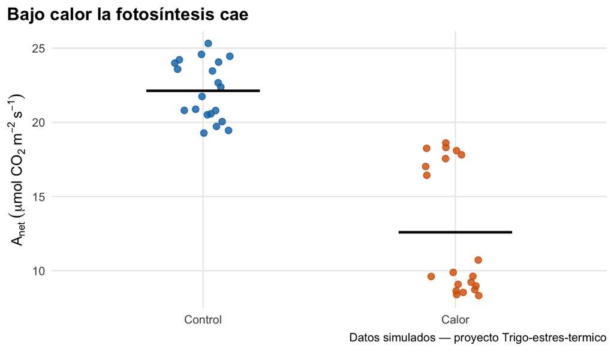

(a) Por tratamiento (n = 20 por grupo).

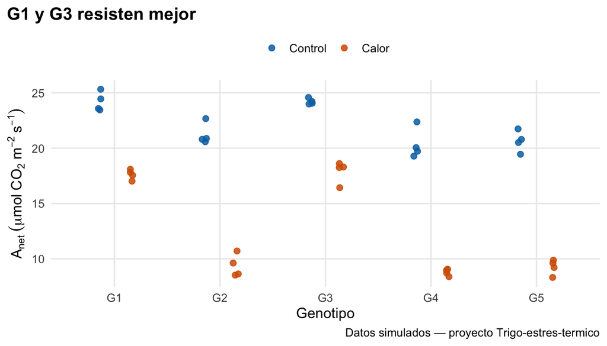

(b) Por genotipo y tratamiento (n = 4 por combinación).

Figura 1: Fotosíntesis neta ($A_{net}$) por tratamiento y por genotipo.

```r
p_trat <- ggplot(datos, aes(tratamiento, A_net, color = tratamiento)) +
  geom_jitter(width = 0.12, size = 2.2, alpha = 0.8) +
  stat_summary(fun = mean, geom = "crossbar", width = 0.45,
               color = "black", linewidth = 0.4) +
  scale_color_manual(values = colores_trat, guide = "none") +
  labs(title = "Bajo calor la fotosíntesis cae",
       x = NULL, y = expression(A[net]~(mu*mol~CO[2]~m^-2~s^-1)),
       caption = fuente) +
  tema
guardar(p_trat, "anet_tratamiento.png")
p_trat
p_gen <- ggplot(datos, aes(genotipo, A_net, color = tratamiento)) +
  geom_point(position = position_jitterdodge(jitter.width = 0.1,
                                             dodge.width = 0.6, seed = 42),
             size = 2, alpha = 0.85) +
  scale_color_manual(values = colores_trat) +
  labs(title = "G1 y G3 resisten mejor",
       x = "Genotipo", y = expression(A[net]~(mu*mol~CO[2]~m^-2~s^-1)),
       color = NULL, caption = fuente) +
  tema
guardar(p_gen, "anet_genotipo.png")
p_gen
```

La media pasa de 22,1 a 12,6 µmol CO<sub>2</sub> m<sup>-2</sup> s<sup>-1</sup>. Pero la nube de puntos bajo calor se ve partida en dos grupos: eso sugiere que los genotipos no responden igual.

## G1 y G3 sostienen casi el doble de fotosíntesis que el resto

**Código**

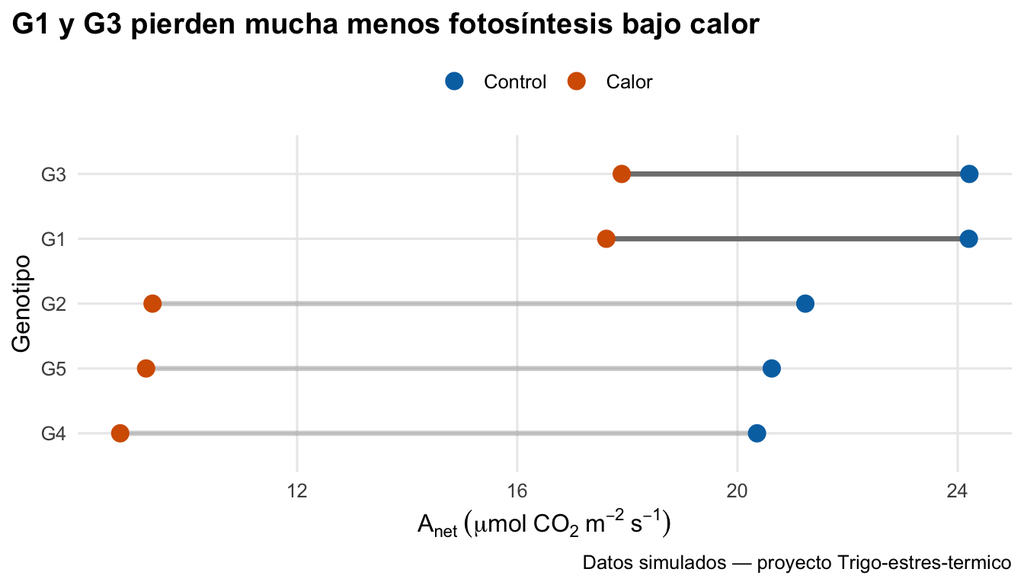

Figura 2: Media de fotosíntesis neta por genotipo en control y calor (n = 4 por combinación). Las líneas unen el mismo genotipo.

```r
destacados <- c("G1", "G3")
p_gen_media <- ggplot(por_genotipo,
       aes(A_net, reorder(genotipo, A_net * (tratamiento == "Calor")))) +
  geom_line(aes(group = genotipo,
                alpha = genotipo %in% destacados), linewidth = 1.2,
            color = "grey50") +
  geom_point(aes(color = tratamiento), size = 3.5) +
  scale_color_manual(values = colores_trat) +
  scale_alpha_manual(values = c(`TRUE` = 1, `FALSE` = 0.35), guide = "none") +
  labs(title = "G1 y G3 pierden mucha menos fotosíntesis bajo calor",
       x = expression(A[net]~(mu*mol~CO[2]~m^-2~s^-1)), y = "Genotipo",
       color = NULL, caption = fuente) +
  tema
guardar(p_gen_media, "genotipos_media.png")
p_gen_media
```

Bajo calor, G1 y G3 mantienen 17,6–17,9 µmol CO<sub>2</sub> m<sup>-2</sup> s<sup>-1</sup>, mientras que G2, G4 y G5 caen a 8,8–9,4. En control los cinco genotipos estaban más próximos.

## El potasio baja un 21,2 % y la prolina sube un 57,6 %

**Código**

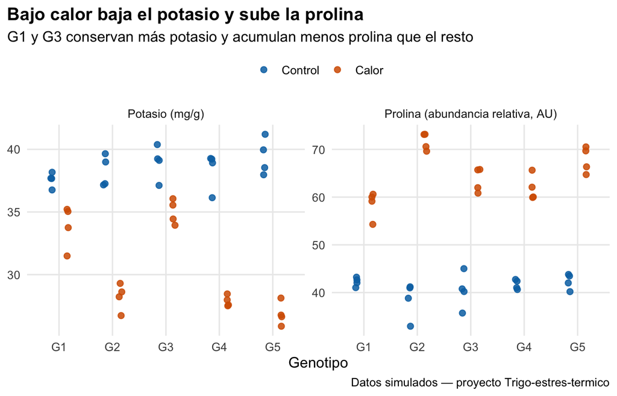

Figura 3: Potasio y prolina por genotipo y tratamiento. Cada punto es una muestra (n = 4 por combinación).

```r
p_k_prolina <- datos %>%
  select(genotipo, tratamiento, K_mg_g, Prolina) %>%
  pivot_longer(c(K_mg_g, Prolina), names_to = "variable") %>%
  mutate(variable = recode(variable,
                           K_mg_g = "Potasio (mg/g)",
                           Prolina = "Prolina (abundancia relativa, AU)")) %>%
  ggplot(aes(genotipo, value, color = tratamiento)) +
  geom_point(position = position_jitterdodge(jitter.width = 0.1,
                                             dodge.width = 0.6, seed = 42),
             size = 2, alpha = 0.85) +
  facet_wrap(~ variable, scales = "free_y") +
  scale_color_manual(values = colores_trat) +
  labs(title = "Bajo calor baja el potasio y sube la prolina",
       subtitle = "G1 y G3 conservan más potasio y acumulan menos prolina que el resto",
       x = "Genotipo", y = NULL, color = NULL, caption = fuente) +
  tema
guardar(p_k_prolina, "k_prolina.png")
p_k_prolina
```

## Cambio por capa de datos

Para ver el panorama completo, las pestañas siguientes muestran el cambio porcentual de cada variable (media de Calor frente a media de Control) en una capa por pestaña. Las pestañas evitan una página larga de tablas en HTML; en PDF y Word se muestran una tras otra. Las tablas son Tabla 1, Tabla 2 y Tabla 3.

**Código**

```r
tabla_cambio <- function(variables) {
  datos %>%
    select(tratamiento, all_of(variables)) %>%
    pivot_longer(-tratamiento, names_to = "variable") %>%
    group_by(variable, tratamiento) %>%
    summarise(media = mean(value), .groups = "drop") %>%
    pivot_wider(names_from = tratamiento, values_from = media) %>%
    mutate(`Cambio (%)` = 100 * (Calor - Control) / Control) %>%
    rename(Variable = variable, `Media Control` = Control, `Media Calor` = Calor) %>%
    arrange(match(Variable, variables))
}
```

**Fisiología**

**Código**

```r
tabla_cambio(c("A_net", "gs", "Ci", "E", "Fv_Fm", "SPAD", "CTD")) %>%
  kable(digits = 2, format.args = list(decimal.mark = ","))
```

Tabla 1: Cambio porcentual Calor frente a Control en variables fisiológicas (A_net, gs, Ci, E en unidades de intercambio gaseoso; Fv/Fm adimensional; SPAD en unidades SPAD; CTD en °C).

| Variable | Media Control | Media Calor | Cambio (%) |
| --- | --- | --- | --- |
| A_net | 22,12 | 12,59 | -43,11 |
| gs | 0,32 | 0,16 | -49,55 |
| Ci | 217,89 | 293,23 | 34,58 |
| E | 3,96 | 2,01 | -49,23 |
| Fv_Fm | 0,82 | 0,72 | -11,61 |
| SPAD | 45,35 | 37,44 | -17,43 |
| CTD | 4,41 | 1,95 | -55,84 |

**Ionómica**

**Código**

```r
tabla_cambio(c("K_mg_g", "Na_mg_g", "Ca_mg_g", "Mg_mg_g", "P_mg_g",
               "Fe_ug_g", "Zn_ug_g", "Mn_ug_g")) %>%
  kable(digits = 2, format.args = list(decimal.mark = ","))
```

Tabla 2: Cambio porcentual Calor frente a Control en nutrientes (macro en mg/g; Fe, Zn y Mn en µg/g).

| Variable | Media Control | Media Calor | Cambio (%) |
| --- | --- | --- | --- |
| K_mg_g | 38,52 | 30,37 | -21,17 |
| Na_mg_g | 1,21 | 1,76 | 46,03 |
| Ca_mg_g | 8,59 | 11,32 | 31,72 |
| Mg_mg_g | 3,21 | 3,21 | 0,05 |
| P_mg_g | 4,06 | 4,10 | 0,82 |
| Fe_ug_g | 109,66 | 108,46 | -1,09 |
| Zn_ug_g | 41,48 | 41,13 | -0,84 |
| Mn_ug_g | 66,96 | 63,24 | -5,56 |

**Metabolómica**

**Código**

```r
tabla_cambio(c("Glucosa", "Fructosa", "Sacarosa", "Rafinosa", "Prolina",
               "GABA", "Malato", "Citrato")) %>%
  kable(digits = 2, format.args = list(decimal.mark = ","))
```

Tabla 3: Cambio porcentual Calor frente a Control en metabolitos (abundancia relativa, AU).

| Variable | Media Control | Media Calor | Cambio (%) |
| --- | --- | --- | --- |
| Glucosa | 124,31 | 98,74 | -20,57 |
| Fructosa | 85,18 | 73,21 | -14,06 |
| Sacarosa | 94,96 | 72,58 | -23,57 |
| Rafinosa | 24,91 | 43,90 | 76,20 |
| Prolina | 41,04 | 64,69 | 57,62 |
| GABA | 49,83 | 69,62 | 39,73 |
| Malato | 69,00 | 60,62 | -12,14 |
| Citrato | 59,44 | 48,92 | -17,70 |

## Bajo calor, las muestras con más potasio tienen más fotosíntesis

**Código**

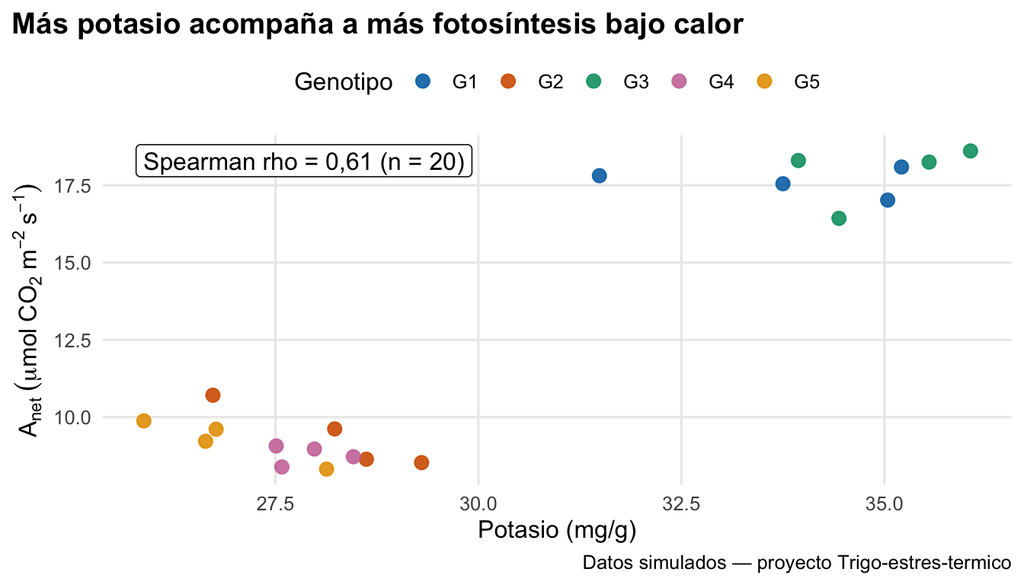

Figura 4: Fotosíntesis neta frente a potasio en las muestras bajo calor (n = 20). Color por genotipo.

```r
p_anet_k <- ggplot(calor, aes(K_mg_g, A_net, color = genotipo)) +
  geom_point(size = 2.8, alpha = 0.9) +
  scale_color_manual(values = c(G1 = "#0072B2", G2 = "#D55E00", G3 = "#009E73",
                                G4 = "#CC79A7", G5 = "#E69F00")) +
  annotate("label", x = -Inf, y = Inf, hjust = -0.1, vjust = 1.3,
           label = paste0("Spearman rho = ", fmt(rho_k, 2), " (n = ", nrow(calor), ")")) +
  labs(title = "Más potasio acompaña a más fotosíntesis bajo calor",
       x = "Potasio (mg/g)",
       y = expression(A[net]~(mu*mol~CO[2]~m^-2~s^-1)),
       color = "Genotipo", caption = fuente) +
  tema
guardar(p_anet_k, "anet_potasio.png")
p_anet_k
```

La asociación es moderada (rho de Spearman = 0,61) y en buena parte refleja la diferencia entre genotipos: G1 y G3 aparecen arriba a la derecha. No permite afirmar que el potasio *cause* la fotosíntesis más alta.

## Un modelo con bloque como efecto fijo

Esta sección se inspira en el capítulo “2w RCBD” del sitio DSFAIR de Paul Schmidt (https://schmidtpaul.github.io/dsfair_quarto/ch/exan/simple/rcbd_gomezgomez1984.html), un sitio hecho con Quarto. Se ajusta un diseño de bloques completos al azar con dos factores y se comparan genotipos dentro de cada tratamiento con medias marginales estimadas (Lenth y Piaskowski 2026) y letras de grupos compartidos (Hothorn, Bretz, y Westfall 2026). La figura usa Wickham, Chang, et al. (2026) y la manipulación de datos Wickham, François, et al. (2026).

**Código**

```r
modelo_anet <- lm(A_net ~ tratamiento * genotipo + bloque, data = datos)

tabla_anova <- car::Anova(modelo_anet, type = "III")
p_interaccion <- tabla_anova["tratamiento:genotipo", "Pr(>F)"]
```

El valor p de la interacción tratamiento × genotipo es <0,001 (Tabla 4): hay evidencia de que los genotipos responden de forma distinta al calor.

**Código**

```r
tabla_anova %>%
  as.data.frame() %>%
  mutate(`Pr(>F)` = case_when(is.na(`Pr(>F)`) ~ "",
                              `Pr(>F)` < 0.001 ~ "<0,001",
                              TRUE ~ format(round(`Pr(>F)`, 3), decimal.mark = ",", nsmall = 3)),
         `F value` = ifelse(is.na(`F value`), "", fmt(`F value`, 2))) %>%
  kable(digits = 3, format.args = list(decimal.mark = ","), align = "r")
```

Tabla 4: ANOVA tipo III de A_net (µmol CO2 m-2 s-1) con tratamiento × genotipo + bloque.

|  | Sum Sq | Df | F value | Pr(>F) |
| --- | --- | --- | --- | --- |
| (Intercept) | 1886,560 | 1 | 3117,04 | <0,001 |
| tratamiento | 86,724 | 1 | 143,29 | <0,001 |
| genotipo | 59,442 | 4 | 24,55 | <0,001 |
| bloque | 5,629 | 3 | 3,10 | 0,043 |
| tratamiento:genotipo | 63,890 | 4 | 26,39 | <0,001 |
| Residuals | 16,341 | 27 |  |  |

**¿Se cumplen los supuestos?**

El diagnóstico se hace sobre los residuos del modelo: normalidad (Shapiro-Wilk) y homogeneidad de varianzas (Levene, paquete `car`). Un callout colapsable mantiene el detalle técnico a mano sin interrumpir la lectura.

**Código**

```r
shapiro_res <- shapiro.test(resid(modelo_anet))
levene_res <- car::leveneTest(A_net ~ tratamiento * genotipo, data = datos)
p_levene <- levene_res[["Pr(>F)"]][1]
```

- Shapiro-Wilk de los residuos: W = 0,963, p = 0,210.
- Levene entre las 10 combinaciones tratamiento × genotipo: p = 0,840.
- Con p > 0,05 en ambas pruebas no hay indicios claros de incumplimiento; con n = 4 por combinación la potencia de estas pruebas es baja.

**Código**

```r
em_genotipo <- emmeans(modelo_anet, ~ genotipo | tratamiento)
cld_genotipo <- multcomp::cld(em_genotipo, adjust = "sidak", Letters = letters) %>%
  as.data.frame() %>%
  mutate(grupo = trimws(.group))

maximos <- datos %>%
  group_by(genotipo, tratamiento) %>%
  summarise(maximo = max(A_net), .groups = "drop")

cld_genotipo <- left_join(cld_genotipo, maximos, by = c("genotipo", "tratamiento"))
```

**Código**

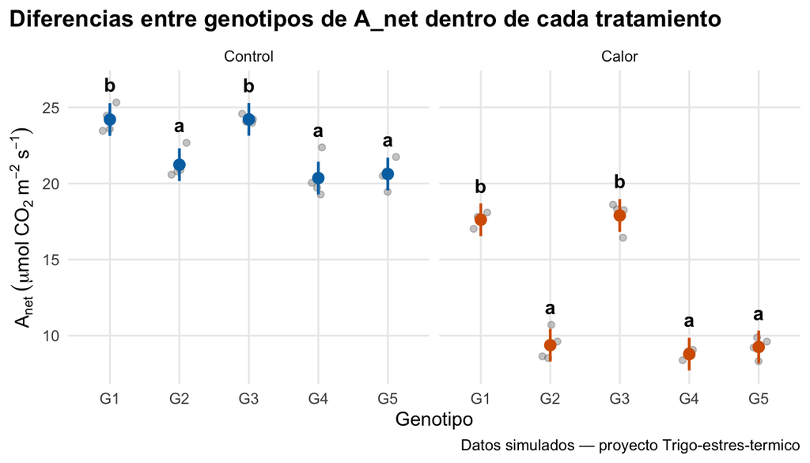

Figura 5: Fotosíntesis neta por genotipo dentro de cada tratamiento. Puntos grises: muestras; puntos de color: media estimada con IC 95 %. Letras iguales dentro de un panel indican genotipos sin diferencia (comparaciones por pares con ajuste de Sidak, alfa = 0,05).

```r
p_modelo <- ggplot() +
  geom_jitter(data = datos, aes(genotipo, A_net),
              width = 0.12, alpha = 0.35, color = "grey40") +
  geom_pointrange(data = cld_genotipo,
                  aes(genotipo, emmean, ymin = lower.CL, ymax = upper.CL,
                      color = tratamiento), linewidth = 0.8) +
  geom_text(data = cld_genotipo, aes(genotipo, pmax(maximo, upper.CL), label = grupo),
            vjust = -0.8, fontface = "bold") +
  facet_wrap(~ tratamiento) +
  scale_color_manual(values = colores_trat, guide = "none") +
  scale_y_continuous(expand = expansion(mult = c(0.05, 0.12))) +
  labs(title = "Diferencias entre genotipos de A_net dentro de cada tratamiento",
       x = "Genotipo", y = expression(A[net]~(mu*mol~CO[2]~m^-2~s^-1)),
       caption = fuente) +
  tema
guardar(p_modelo, "modelo_emmeans.png")
p_modelo
```

## Mensaje final: hay genotipos más tolerantes, y el potasio es una pista

- El calor reduce la fotosíntesis neta (−43,1 %) y el potasio (−21,2 %), y aumenta la prolina (+57,6 %).
- **G1 y G3** sostienen casi el doble de fotosíntesis que el resto bajo calor. Son candidatos a estudiar.
- La relación entre potasio y fotosíntesis sugiere una hipótesis para probar en un experimento: que el mantenimiento del potasio contribuya a la tolerancia.

### Limitaciones

- **Datos simulados:** sirven para practicar el análisis, no para sacar conclusiones agronómicas.
- **Modelo simple:** el modelo de A_net incluye el bloque como efecto fijo, pero solo cubre una variable; el resto del análisis sigue siendo descriptivo.
- **n pequeño:** 4 muestras por genotipo y tratamiento, lo que limita la potencia de los diagnósticos y de las comparaciones.
- **Correlación no es causalidad:** la asociación entre potasio y fotosíntesis puede deberse al genotipo.

### Próximos pasos

Ajustar un modelo mixto (tratamiento × genotipo, con bloque como efecto aleatorio) y hacer un PCA de las tres capas para ver si G1 y G3 se separan también en el perfil metabólico.

## Referencias

Hothorn, Torsten, Frank Bretz, y Peter Westfall. 2026. *multcomp: Simultaneous Inference in General Parametric Models*. https://codeberg.org/thothorn/multcomp.

Lenth, Russell V., y Julia Piaskowski. 2026. *emmeans: Estimated Marginal Means, aka Least-Squares Means*. https://rvlenth.github.io/emmeans/.

Wickham, Hadley, Winston Chang, Lionel Henry, Thomas Lin Pedersen, Kohske Takahashi, Claus Wilke, Kara Woo, Hiroaki Yutani, Dewey Dunnington, y Teun van den Brand. 2026. *ggplot2: Create Elegant Data Visualisations Using the Grammar of Graphics*. https://ggplot2.tidyverse.org.

Wickham, Hadley, Romain François, Lionel Henry, Kirill Müller, y Davis Vaughan. 2026. *dplyr: A Grammar of Data Manipulation*. https://dplyr.tidyverse.org.

**Código**

## Notas

[^1]: Los datos se generaron por simulación; no hay procedencia ni licencia externas. Se documenta aquí para cumplir la norma de integridad de datos del curso.